# Final COVID Tables and Figures

```r
library(ggplot2)
library(ggpubr)
library(dplyr)
library(stringr)
```

```r
make_covid_plot <- function(drug_outcome_0_0,
                            drug_outcome_0_1,
                            drug_outcome_1_0,
                            drug_outcome_1_1,
                            p,
                            p_star,
                            plot_title,
                            receptor){
  p_round <- 3
  n_drug = drug_outcome_1_0 + drug_outcome_1_1
  n_control = drug_outcome_0_0 + drug_outcome_0_1
  outcome_rates <- c(drug_outcome_0_1 / n_control,
                     drug_outcome_1_1 / n_drug)
  base_vent_mat <- matrix(c(rep(c(0,0),drug_outcome_0_0),
                            rep(c(0,1),drug_outcome_0_1),
                            rep(c(1,0),drug_outcome_1_0),
                            rep(c(1,1),drug_outcome_1_1)),
                          ncol=2,
                          byrow=TRUE)
  df <- base_vent_mat %>%
    as.data.frame()
  colnames(df) <- c("drug", "outcome")
  df <- df %>%
    mutate(drug = factor(drug))
  label_offset <- .05
  annot_font_size <- 3.75
  df %>%
    group_by(drug) %>%
    summarize(outcome_rate = mean(outcome), n = str_c("n = ",n()))%>%
    ggplot(aes(x = drug, y = outcome_rate, group = drug, fill = drug)) +
    geom_col(position = 'dodge') +
    annotate("segment", x = 1, xend = 1, y = outcome_rates[1], yend = 1.1*max(outcome_rates), colour = "black") +
    annotate("segment", x = 2, xend = 2, y = outcome_rates[2], yend = 1.1*max(outcome_rates), colour = "black") +
    annotate("segment", x = 1, xend = 2, y = 1.1*max(outcome_rates), yend = 1.1*max(outcome_rates), colour = "black") +
    labs(title = plot_title,
         x = "",
         y = "") +
    annotate("text", x = 1 + label_offset, y = 0.05 * max(outcome_rates), hjust = 0, label = "Control", vjust = 0) +
    annotate("text", x = 2 - label_offset, y = 0.05 * max(outcome_rates), hjust = 0, vjust = 1,
             label = str_c("n = ", n_drug), size = annot_font_size) +
    annotate("text", x = 2 + label_offset, y = 0.05 * max(outcome_rates), hjust = 0, label = ifelse(receptor=="alpha",
                                                                                                    expression(alpha[1]*"-AR Antagonist"),
                                                                                                    expression(beta[1]*"-AR Antagonist")),
             vjust = 0) +
    annotate("text", x = 1 - label_offset, y = 0.05 * max(outcome_rates), hjust = 0, vjust = 1,
             label = str_c("n = ", n_control), size = annot_font_size) +
    annotate("text", x = 1.5, y = 1.125*max(outcome_rates), label = "p\np*", hjust = 0, vjust = .5, size = annot_font_size) +
    annotate("text", x = 1.5, y = 1.2*max(outcome_rates), label = str_c("= ", round(p,p_round), "\n= ", ifelse(round(p_star,p_round)!=0,round(p_star,p_round),round(p_star,p_round+1))),
             hjust = 0, vjust = .5, size = annot_font_size) +
    scale_y_continuous(breaks=c(0, outcome_rates), labels = scales::percent(c(0, round(outcome_rates,3)))) +
    scale_fill_manual(values = c("gray80", "gray90")) +
    guides(fill = "none") +
    expand_limits(y=c(0, 1.4*max(outcome_rates))) +
    theme_bw() +
    theme(panel.grid.major = element_blank(), panel.grid.minor = element_blank()) +
    theme(panel.border = element_blank()) +
    theme(axis.text.y = element_blank(),
        axis.ticks.y = element_blank()) +
    theme(plot.title = element_text(size=12)) +
    coord_flip()
}
```

# 1 ARDS

## 1.1 Alpha Blockers

### 1.1.1 Ventilation vs. Alpha

```r
#          vent.out
# alpha.alt     0     1
#         0 10464  2006
#         1   573    82

drug_outcome_0_0 <- 10464
drug_outcome_0_1 <- 2006
drug_outcome_1_0 <- 573
drug_outcome_1_1 <- 82
```

#### 1.1.1.1 Unadjusted

```
Call:
glm(formula = vent.out ~ alpha.alt, family = binomial(link = "logit"))

Deviance Residuals:
Min       1Q   Median       3Q      Max
-0.5923  -0.5923  -0.5923  -0.5923   2.0386

Coefficients:
Estimate Std. Error z value Pr(>|z|)
(Intercept) -1.65180    0.02437 -67.770   <2e-16 ***
alpha.alt   -0.29237    0.12056  -2.425   0.0153 *
---
Signif. codes:  0 ‘***’ 0.001 ‘**’ 0.01 ‘*’ 0.05 ‘.’ 0.1 ‘ ’ 1

(Dispersion parameter for binomial family taken to be 1)

Null deviance: 11501  on 13124  degrees of freedom
Residual deviance: 11495  on 13123  degrees of freedom
AIC: 11499

Number of Fisher Scoring iterations: 4

> print(exp(cbind(coef(dvent.alpha), confint(dvent.alpha, level=0.95))))
2.5 %    97.5 %
(Intercept) 0.1917049 0.1827145 0.2010337
alpha.alt   0.7464935 0.5854430 0.9396983
```

```r
# OR, CI, and p statement example:
# OR 0.75, 95% CI (0.59, 0.94), p=0.015
p = 0.0153
OR_CI = c(0.7464935,0.5854430,0.9396983)
OR = OR_CI[1]
CI = OR_CI[2:3]
str_c("OR ", round(OR,2), ", 95% CI (", round(CI[1],2), ", ", round(CI[2],2), "), p=", round(p,3))
```

```
## [1] "OR 0.75, 95% CI (0.59, 0.94), p=0.015"
```

#### 1.1.1.2 Adjusted

```
Call:
glm(formula = vent.out ~ alpha.alt + beta.alt + YEARf + AGE +
SEX + AGE2 + AGE3 + DM + HTN + HF + IHD + AMI + COPD + PTSD,
family = binomial(link = "logit"))
Deviance Residuals:
Min       1Q   Median       3Q      Max
-0.8371  -0.6133  -0.5776  -0.5083   2.3746
Coefficients: (1 not defined because of singularities)
Estimate Std. Error z value Pr(>|z|)
(Intercept) -2.308e+01  2.790e+01  -0.827  0.40809
alpha.alt   -2.868e-01  1.221e-01  -2.348  0.01885 *
beta.alt     4.844e-02  6.697e-02   0.723  0.46945
YEARf2008    9.471e-01  3.750e-01   2.526  0.01154 *
YEARf2009    1.060e+00  3.724e-01   2.847  0.00441 **
YEARf2010    8.577e-01  3.736e-01   2.296  0.02168 *
YEARf2011    8.001e-01  3.737e-01   2.141  0.03228 *
YEARf2012    7.797e-01  3.734e-01   2.088  0.03676 *
YEARf2013    7.209e-01  3.754e-01   1.920  0.05482 .
YEARf2014    7.670e-01  3.749e-01   2.046  0.04079 *
YEARf2015    7.478e-01  3.804e-01   1.966  0.04930 *
AGE          1.160e+00  1.537e+00   0.754  0.45069
SEX                 NA         NA      NA       NA
AGE2        -2.145e-02  2.808e-02  -0.764  0.44480
AGE3         1.305e-04  1.700e-04   0.768  0.44259
DM           5.883e-02  5.412e-02   1.087  0.27703
HTN          7.229e-02  5.358e-02   1.349  0.17732
HF           1.077e-01  6.823e-02   1.578  0.11453
IHD         -3.495e-01  6.154e-02  -5.680 1.35e-08 ***
AMI          4.152e-01  1.291e-01   3.217  0.00130 **
COPD        -1.672e-02  5.454e-02  -0.307  0.75911
PTSD         3.732e-01  3.159e-01   1.181  0.23745
---
Signif. codes:  0 '***' 0.001 '**' 0.01 '*' 0.05 '.' 0.1 ‘ ’ 1
(Dispersion parameter for binomial family taken to be 1)
Null deviance: 11501  on 13124  degrees of freedom
Residual deviance: 11422  on 13104  degrees of freedom
AIC: 11464
Number of Fisher Scoring iterations: 4

> print(exp(cbind(coef(vent.alpha.all), confint(vent.alpha.all))))
```

[output cut: 8 more lines]

```
YEARf2012   2.180916e+00 1.116016e+00 4.923007e+00
YEARf2013   2.056225e+00 1.047171e+00 4.656387e+00
YEARf2014   2.153264e+00 1.097795e+00 4.872595e+00
YEARf2015   2.112310e+00 1.063237e+00 4.820730e+00
AGE         3.188734e+00 1.574697e-01 6.531005e+01
SEX                   NA           NA           NA
AGE2        9.787737e-01 9.262788e-01 1.034071e+00
AGE3        1.000131e+00 9.997977e-01 1.000464e+00
DM          1.060596e+00 9.535467e-01 1.178938e+00
HTN         1.074964e+00 9.679442e-01 1.194215e+00
HF          1.113682e+00 9.733777e-01 1.271915e+00
IHD         7.050190e-01 6.244151e-01 7.948018e-01
AMI         1.514686e+00 1.170608e+00 1.942588e+00
COPD        9.834148e-01 8.832573e-01 1.093830e+00
PTSD        1.452344e+00 7.507619e-01 2.617486e+00
```

```r
# OR, CI, and p statement example:
# OR 0.75, 95% CI (0.59, 0.94), p=0.015
p_star = 0.01885
OR_CI = c(7.506926e-01, 5.870463e-01, 9.479992e-01)
OR = OR_CI[1]
CI = OR_CI[2:3]
str_c("AOR ", round(OR,2), ", 95% CI (", round(CI[1],2), ", ", round(CI[2],2), "), p=", round(p_star,3))
```

```
## [1] "AOR 0.75, 95% CI (0.59, 0.95), p=0.019"
```

#### 1.1.1.3 Figure

Results for Figure:

```r
plot_title = "Percentage of ARDS patients\nrequiring ventilation"
receptor = "alpha"
prop.test(x = c(drug_outcome_0_1,  # bad outcome controls
                drug_outcome_1_1), # bad outcome on drugs
          n = c(drug_outcome_0_0 + drug_outcome_0_1,  # total controls
                drug_outcome_1_0 + drug_outcome_1_1)) # total on drugs
```

```
##
##  2-sample test for equality of proportions with continuity correction
##
## data:  c(drug_outcome_0_1, drug_outcome_1_1) out of c(drug_outcome_0_0 + drug_outcome_0_1, drug_outcome_1_0 + drug_outcome_1_1)
## X-squared = 5.6568, df = 1, p-value = 0.01739
## alternative hypothesis: two.sided
## 95 percent confidence interval:
##  0.008720529 0.062629949
## sample estimates:
##    prop 1    prop 2
## 0.1608661 0.1251908
```

Figure:

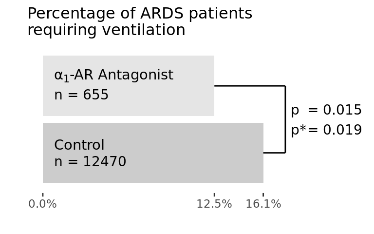

```r
p1 <- make_covid_plot(drug_outcome_0_0, drug_outcome_0_1, drug_outcome_1_0, drug_outcome_1_1,
                p, p_star, plot_title,receptor)
p1
```

### 1.1.2 Ventilation and Death vs. Alpha

```r
#          deathANDvent
# alpha.alt     0     1
#         0 11994   476
#         1   639    16

drug_outcome_0_0 <- 11994
drug_outcome_0_1 <- 476
drug_outcome_1_0 <- 639
drug_outcome_1_1 <- 16
```

#### 1.1.2.1 Unadjusted

```
Call:
glm(formula = deathANDvent ~ alpha.alt, family = binomial(link = "logit"))

Deviance Residuals:
Min      1Q  Median      3Q     Max
-0.279  -0.279  -0.279  -0.279   2.725

Coefficients:
Estimate Std. Error z value Pr(>|z|)
(Intercept) -3.22674    0.04674 -69.043   <2e-16 ***
alpha.alt   -0.46057    0.25739  -1.789   0.0735 .
---
Signif. codes:  0 ‘***’ 0.001 ‘**’ 0.01 ‘*’ 0.05 ‘.’ 0.1 ‘ ’ 1

(Dispersion parameter for binomial family taken to be 1)

Null deviance: 4196.6  on 13124  degrees of freedom
Residual deviance: 4192.9  on 13123  degrees of freedom
AIC: 4196.9

Number of Fisher Scoring iterations: 6

> print(exp(cbind(coef(dvent.alpha), confint(dvent.alpha, level=0.95))))
2.5 %     97.5 %
(Intercept) 0.03968651 0.03616518 0.04343815
alpha.alt   0.63092279 0.36554511 1.00935119
```

```r
# OR, CI, and p statement example:
# OR 0.75, 95% CI (0.59, 0.94), p=0.015
p = 0.0735
OR_CI = c(0.63092279, 0.36554511, 1.00935119)
OR = OR_CI[1]
CI = OR_CI[2:3]
str_c("OR ", round(OR,2), ", 95% CI (", round(CI[1],2), ", ", round(CI[2],2), "), p=", round(p,3))
```

```
## [1] "OR 0.63, 95% CI (0.37, 1.01), p=0.074"
```

#### 1.1.2.2 Adjusted

```
Call:
glm(formula = deathANDvent ~ alpha.alt + beta.alt + YEARf + AGE +
SEX + AGE2 + AGE3 + DM + HTN + HF + IHD + AMI + COPD + PTSD,
family = binomial(link = "logit"))
Deviance Residuals:
Min       1Q   Median       3Q      Max
-0.4172  -0.2979  -0.2720  -0.2440   2.9704
Coefficients: (1 not defined because of singularities)
Estimate Std. Error z value Pr(>|z|)
(Intercept) -1.206e+00  5.620e+01  -0.021 0.982876
alpha.alt   -5.269e-01  2.596e-01  -2.030 0.042393 *
beta.alt     1.284e-01  1.258e-01   1.021 0.307446
YEARf2008    7.149e-01  7.284e-01   0.982 0.326329
YEARf2009    8.955e-01  7.226e-01   1.239 0.215215
YEARf2010    6.155e-01  7.259e-01   0.848 0.396489
YEARf2011    7.249e-01  7.249e-01   1.000 0.317253
YEARf2012    6.316e-01  7.248e-01   0.871 0.383515
YEARf2013    5.203e-01  7.297e-01   0.713 0.475881
YEARf2014    8.309e-01  7.256e-01   1.145 0.252126
YEARf2015    6.775e-01  7.370e-01   0.919 0.357967
AGE         -2.360e-01  3.085e+00  -0.077 0.939011
SEX                 NA         NA      NA       NA
AGE2         5.402e-03  5.612e-02   0.096 0.923323
AGE3        -3.686e-05  3.386e-04  -0.109 0.913307
DM          -5.824e-02  1.049e-01  -0.555 0.578626
HTN          7.386e-02  1.030e-01   0.717 0.473479
HF           1.862e-01  1.273e-01   1.463 0.143475
IHD         -4.680e-01  1.211e-01  -3.866 0.000111 ***
AMI          2.426e-01  2.623e-01   0.925 0.355046
COPD         1.970e-01  1.008e-01   1.955 0.050576 .
PTSD         3.057e-01  5.963e-01   0.513 0.608204
---
Signif. codes:  0 '***' 0.001 '**' 0.01 '*' 0.05 '.' 0.1 ‘ ’ 1
(Dispersion parameter for binomial family taken to be 1)
Null deviance: 4196.6  on 13124  degrees of freedom
Residual deviance: 4159.0  on 13104  degrees of freedom
AIC: 4201
Number of Fisher Scoring iterations: 6

> print(exp(cbind(coef(dvent.alpha.all), confint(dvent.alpha.all))))
```

[output cut: 8 more lines]

```
YEARf2012   1.8806887 5.784374e-01 1.155475e+01
YEARf2013   1.6824639 5.101042e-01 1.039737e+01
YEARf2014   2.2954122 7.044750e-01 1.411522e+01
YEARf2015   1.9689616 5.843044e-01 1.227371e+01
AGE         0.7897764 1.941076e-03 3.499951e+02
SEX                NA           NA           NA
AGE2        1.0054162 9.000196e-01 1.121700e+00
AGE3        0.9999631 9.993025e-01 1.000631e+00
DM          0.9434269 7.666543e-01 1.156699e+00
HTN         1.0766565 8.804403e-01 1.318878e+00
HF          1.2047128 9.345164e-01 1.539948e+00
IHD         0.6262438 4.918951e-01 7.909654e-01
AMI         1.2745500 7.389536e-01 2.078648e+00
COPD        1.2177664 9.975643e-01 1.481182e+00
PTSD        1.3575522 3.293397e-01 3.708113e+00
```

```r
# OR, CI, and p statement example:
# OR 0.75, 95% CI (0.59, 0.94), p=0.015
p_star = 0.042393
OR_CI = c(0.5904084, 3.407872e-01, 9.492965e-01)
OR = OR_CI[1]
CI = OR_CI[2:3]
str_c("AOR ", round(OR,2), ", 95% CI (", round(CI[1],2), ", ", round(CI[2],2), "), p=", round(p_star,3))
```

```
## [1] "AOR 0.59, 95% CI (0.34, 0.95), p=0.042"
```

#### 1.1.2.3 Figure

Results for Figure:

```r
plot_title = "Percentage of ARDS patients experiencing\nventilation and in-hospital death"
receptor = "alpha"
prop.test(x = c(drug_outcome_0_1,  # bad outcome controls
                drug_outcome_1_1), # bad outcome on drugs
          n = c(drug_outcome_0_0 + drug_outcome_0_1,  # total controls
                drug_outcome_1_0 + drug_outcome_1_1)) # total on drugs
```

```
##
##  2-sample test for equality of proportions with continuity correction
##
## data:  c(drug_outcome_0_1, drug_outcome_1_1) out of c(drug_outcome_0_0 + drug_outcome_0_1, drug_outcome_1_0 + drug_outcome_1_1)
## X-squared = 2.8883, df = 1, p-value = 0.08922
## alternative hypothesis: two.sided
## 95 percent confidence interval:
##  0.0006494828 0.0268387791
## sample estimates:
##     prop 1     prop 2
## 0.03817161 0.02442748
```

Figure:

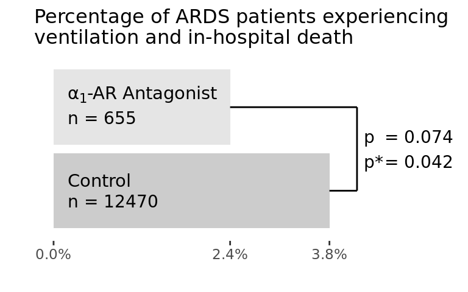

```r
p2 <- make_covid_plot(drug_outcome_0_0, drug_outcome_0_1, drug_outcome_1_0, drug_outcome_1_1,
                p, p_star, plot_title,receptor)
p2
```

## 1.2 Beta Blockers

### 1.2.1 Ventilation vs. Beta

```r
#      vent.out
# drugs    0    1
#     0 9206 1744
#     1 1831  344

drug_outcome_0_0 <- 9206
drug_outcome_0_1 <- 1744
drug_outcome_1_0 <- 1831
drug_outcome_1_1 <- 344
```

#### 1.2.1.1 Unadjusted

```
Call:
glm(formula = vent.out ~ beta.alt, family = binomial(link = “logit”))
Deviance Residuals:
Min 1Q Median 3Q Max
-0.5890 -0.5890 -0.5890 -0.5868 1.9205
Coefficients:
Estimate Std. Error z value Pr(>|z|)
(Intercept) -1.663674 0.026115 -63.705 <2e-16 ***
beta.alt -0.008302 0.064305 -0.129 0.897
---
Signif. codes: 0 ‘***’ 0.001 ‘**’ 0.01 ‘*’ 0.05 ‘.’ 0.1 ‘ ’ 1
(Dispersion parameter for binomial family taken to be 1)
Null deviance: 11501 on 13124 degrees of freedom
Residual deviance: 11501 on 13123 degrees of freedom
AIC: 11505
Number of Fisher Scoring iterations: 3

2.5 % 97.5 %
(Intercept) 0.1894417 0.1799348 0.199332
beta.alt 0.9917326 0.8732018 1.123618
```

```r
# OR, CI, and p statement example:
# OR 0.75, 95% CI (0.59, 0.94), p=0.015
p = 0.897
OR_CI = c(0.9917326, 0.8732018, 1.123618)
OR = OR_CI[1]
CI = OR_CI[2:3]
str_c("OR ", round(OR,2), ", 95% CI (", round(CI[1],2), ", ", round(CI[2],2), "), p=", round(p,3))
```

```
## [1] "OR 0.99, 95% CI (0.87, 1.12), p=0.897"
```

#### 1.2.1.2 Adjusted

```
Call:
glm(formula = vent.out ~ alpha.alt + beta.alt + YEARf + AGE +
SEX + AGE2 + AGE3 + DM + HTN + HF + IHD + AMI + COPD + PTSD,
family = binomial(link = "logit"))
Deviance Residuals:
Min       1Q   Median       3Q      Max
-0.8371  -0.6133  -0.5776  -0.5083   2.3746
Coefficients: (1 not defined because of singularities)
Estimate Std. Error z value Pr(>|z|)
(Intercept) -2.308e+01  2.790e+01  -0.827  0.40809
alpha.alt   -2.868e-01  1.221e-01  -2.348  0.01885 *
beta.alt     4.844e-02  6.697e-02   0.723  0.46945
YEARf2008    9.471e-01  3.750e-01   2.526  0.01154 *
YEARf2009    1.060e+00  3.724e-01   2.847  0.00441 **
YEARf2010    8.577e-01  3.736e-01   2.296  0.02168 *
YEARf2011    8.001e-01  3.737e-01   2.141  0.03228 *
YEARf2012    7.797e-01  3.734e-01   2.088  0.03676 *
YEARf2013    7.209e-01  3.754e-01   1.920  0.05482 .
YEARf2014    7.670e-01  3.749e-01   2.046  0.04079 *
YEARf2015    7.478e-01  3.804e-01   1.966  0.04930 *
AGE          1.160e+00  1.537e+00   0.754  0.45069
SEX                 NA         NA      NA       NA
AGE2        -2.145e-02  2.808e-02  -0.764  0.44480
AGE3         1.305e-04  1.700e-04   0.768  0.44259
DM           5.883e-02  5.412e-02   1.087  0.27703
HTN          7.229e-02  5.358e-02   1.349  0.17732
HF           1.077e-01  6.823e-02   1.578  0.11453
IHD         -3.495e-01  6.154e-02  -5.680 1.35e-08 ***
AMI          4.152e-01  1.291e-01   3.217  0.00130 **
COPD        -1.672e-02  5.454e-02  -0.307  0.75911
PTSD         3.732e-01  3.159e-01   1.181  0.23745
---
Signif. codes:  0 '***' 0.001 '**' 0.01 '*' 0.05 '.' 0.1 ‘ ’ 1
(Dispersion parameter for binomial family taken to be 1)
Null deviance: 11501  on 13124  degrees of freedom
Residual deviance: 11422  on 13104  degrees of freedom
AIC: 11464
Number of Fisher Scoring iterations: 4

> print(exp(cbind(coef(vent.alpha.all), confint(vent.alpha.all))))
```

[output cut: 8 more lines]

```
YEARf2012   2.180916e+00 1.116016e+00 4.923007e+00
YEARf2013   2.056225e+00 1.047171e+00 4.656387e+00
YEARf2014   2.153264e+00 1.097795e+00 4.872595e+00
YEARf2015   2.112310e+00 1.063237e+00 4.820730e+00
AGE         3.188734e+00 1.574697e-01 6.531005e+01
SEX                   NA           NA           NA
AGE2        9.787737e-01 9.262788e-01 1.034071e+00
AGE3        1.000131e+00 9.997977e-01 1.000464e+00
DM          1.060596e+00 9.535467e-01 1.178938e+00
HTN         1.074964e+00 9.679442e-01 1.194215e+00
HF          1.113682e+00 9.733777e-01 1.271915e+00
IHD         7.050190e-01 6.244151e-01 7.948018e-01
AMI         1.514686e+00 1.170608e+00 1.942588e+00
COPD        9.834148e-01 8.832573e-01 1.093830e+00
PTSD        1.452344e+00 7.507619e-01 2.617486e+00
```

```r
# OR, CI, and p statement example:
# OR 0.75, 95% CI (0.59, 0.94), p=0.015
p_star = 0.46945
OR_CI = c(1.049634e+00, 9.194939e-01, 1.195598e+00)
OR = OR_CI[1]
CI = OR_CI[2:3]
str_c("AOR ", round(OR,2), ", 95% CI (", round(CI[1],2), ", ", round(CI[2],2), "), p=", round(p_star,3))
```

```
## [1] "AOR 1.05, 95% CI (0.92, 1.2), p=0.469"
```

#### 1.2.1.3 Figure

Results for Figure:

```r
plot_title = "Percentage of ARDS patients\nrequiring ventilation"
receptor = "beta"
prop.test(x = c(drug_outcome_0_1,  # bad outcome controls
                drug_outcome_1_1), # bad outcome on drugs
          n = c(drug_outcome_0_0 + drug_outcome_0_1,  # total controls
                drug_outcome_1_0 + drug_outcome_1_1)) # total on drugs
```

```
##
##  2-sample test for equality of proportions with continuity correction
##
## data:  c(drug_outcome_0_1, drug_outcome_1_1) out of c(drug_outcome_0_0 + drug_outcome_0_1, drug_outcome_1_0 + drug_outcome_1_1)
## X-squared = 0.0094106, df = 1, p-value = 0.9227
## alternative hypothesis: two.sided
## 95 percent confidence interval:
##  -0.01596398  0.01818095
## sample estimates:
##    prop 1    prop 2
## 0.1592694 0.1581609
```

Figure:

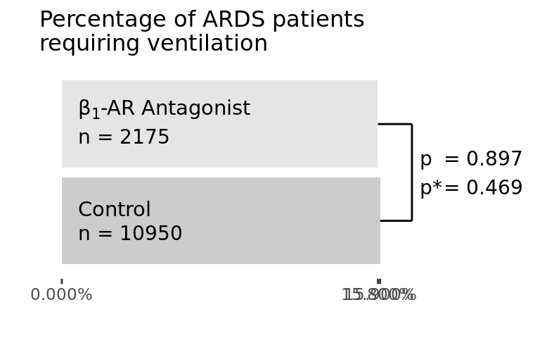

```r
p3 <- make_covid_plot(drug_outcome_0_0, drug_outcome_0_1, drug_outcome_1_0, drug_outcome_1_1,
                p, p_star, plot_title,receptor)
p3
```

### 1.2.2 Ventilation and Death vs. Beta

```r
#          deathANDvent
# beta.alt      0     1
#         0 10544   406
#         1  2089    86

drug_outcome_0_0 <- 10544
drug_outcome_0_1 <- 406
drug_outcome_1_0 <- 2089
drug_outcome_1_1 <- 86
```

#### 1.2.2.1 Unadjusted

```
Call:
glm(formula = deathANDvent ~ beta.alt, family = binomial(link = “logit”))
Deviance Residuals:
Min 1Q Median 3Q Max
-0.2841 -0.2749 -0.2749 -0.2749 2.5670
Coefficients:
Estimate Std. Error z value Pr(>|z|)
(Intercept) -3.25696 0.05058 -64.398 <2e-16 ***
beta.alt 0.06687 0.12110 0.552 0.581
---
Signif. codes: 0 ‘***’ 0.001 ‘**’ 0.01 ‘*’ 0.05 ‘.’ 0.1 ‘ ’ 1
(Dispersion parameter for binomial family taken to be 1)
Null deviance: 4196.6 on 13124 degrees of freedom
Residual deviance: 4196.3 on 13123 degrees of freedom
AIC: 4200.3
Number of Fisher Scoring iterations: 6

2.5 % 97.5 %
(Intercept) 0.03850531 0.03481766 0.04245437
beta.alt 1.06915181 0.83826677 1.34832320
```

```r
# OR, CI, and p statement example:
# OR 0.75, 95% CI (0.59, 0.94), p=0.015
p = 0.581
OR_CI = c(1.06915181, 0.83826677, 1.34832320)
OR = OR_CI[1]
CI = OR_CI[2:3]
str_c("OR ", round(OR,2), ", 95% CI (", round(CI[1],2), ", ", round(CI[2],2), "), p=", round(p,3))
```

```
## [1] "OR 1.07, 95% CI (0.84, 1.35), p=0.581"
```

#### 1.2.2.2 Adjusted

```
Call:
glm(formula = deathANDvent ~ alpha.alt + beta.alt + YEARf + AGE +
SEX + AGE2 + AGE3 + DM + HTN + HF + IHD + AMI + COPD + PTSD,
family = binomial(link = "logit"))
Deviance Residuals:
Min       1Q   Median       3Q      Max
-0.4172  -0.2979  -0.2720  -0.2440   2.9704
Coefficients: (1 not defined because of singularities)
Estimate Std. Error z value Pr(>|z|)
(Intercept) -1.206e+00  5.620e+01  -0.021 0.982876
alpha.alt   -5.269e-01  2.596e-01  -2.030 0.042393 *
beta.alt     1.284e-01  1.258e-01   1.021 0.307446
YEARf2008    7.149e-01  7.284e-01   0.982 0.326329
YEARf2009    8.955e-01  7.226e-01   1.239 0.215215
YEARf2010    6.155e-01  7.259e-01   0.848 0.396489
YEARf2011    7.249e-01  7.249e-01   1.000 0.317253
YEARf2012    6.316e-01  7.248e-01   0.871 0.383515
YEARf2013    5.203e-01  7.297e-01   0.713 0.475881
YEARf2014    8.309e-01  7.256e-01   1.145 0.252126
YEARf2015    6.775e-01  7.370e-01   0.919 0.357967
AGE         -2.360e-01  3.085e+00  -0.077 0.939011
SEX                 NA         NA      NA       NA
AGE2         5.402e-03  5.612e-02   0.096 0.923323
AGE3        -3.686e-05  3.386e-04  -0.109 0.913307
DM          -5.824e-02  1.049e-01  -0.555 0.578626
HTN          7.386e-02  1.030e-01   0.717 0.473479
HF           1.862e-01  1.273e-01   1.463 0.143475
IHD         -4.680e-01  1.211e-01  -3.866 0.000111 ***
AMI          2.426e-01  2.623e-01   0.925 0.355046
COPD         1.970e-01  1.008e-01   1.955 0.050576 .
PTSD         3.057e-01  5.963e-01   0.513 0.608204
---
Signif. codes:  0 '***' 0.001 '**' 0.01 '*' 0.05 '.' 0.1 ‘ ’ 1
(Dispersion parameter for binomial family taken to be 1)
Null deviance: 4196.6  on 13124  degrees of freedom
Residual deviance: 4159.0  on 13104  degrees of freedom
AIC: 4201
Number of Fisher Scoring iterations: 6

> print(exp(cbind(coef(dvent.alpha.all), confint(dvent.alpha.all))))
```

[output cut: 8 more lines]

```
YEARf2012   1.8806887 5.784374e-01 1.155475e+01
YEARf2013   1.6824639 5.101042e-01 1.039737e+01
YEARf2014   2.2954122 7.044750e-01 1.411522e+01
YEARf2015   1.9689616 5.843044e-01 1.227371e+01
AGE         0.7897764 1.941076e-03 3.499951e+02
SEX                NA           NA           NA
AGE2        1.0054162 9.000196e-01 1.121700e+00
AGE3        0.9999631 9.993025e-01 1.000631e+00
DM          0.9434269 7.666543e-01 1.156699e+00
HTN         1.0766565 8.804403e-01 1.318878e+00
HF          1.2047128 9.345164e-01 1.539948e+00
IHD         0.6262438 4.918951e-01 7.909654e-01
AMI         1.2745500 7.389536e-01 2.078648e+00
COPD        1.2177664 9.975643e-01 1.481182e+00
PTSD        1.3575522 3.293397e-01 3.708113e+00
```

```r
# OR, CI, and p statement example:
# OR 0.75, 95% CI (0.59, 0.94), p=0.015
p_star = 0.307446
OR_CI = c(1.1370539, 8.837020e-01, 1.448122e+00)
OR = OR_CI[1]
CI = OR_CI[2:3]
str_c("AOR ", round(OR,2), ", 95% CI (", round(CI[1],2), ", ", round(CI[2],2), "), p=", round(p_star,3))
```

```
## [1] "AOR 1.14, 95% CI (0.88, 1.45), p=0.307"
```

#### 1.2.2.3 Figure

Results for Figure:

```r
plot_title = "Percentage of ARDS patients experiencing\nventilation and in-hospital death"
receptor = "beta"
prop.test(x = c(drug_outcome_0_1,  # bad outcome controls
                drug_outcome_1_1), # bad outcome on drugs
          n = c(drug_outcome_0_0 + drug_outcome_0_1,  # total controls
                drug_outcome_1_0 + drug_outcome_1_1)) # total on drugs
```

```
##
##  2-sample test for equality of proportions with continuity correction
##
## data:  c(drug_outcome_0_1, drug_outcome_1_1) out of c(drug_outcome_0_0 + drug_outcome_0_1, drug_outcome_1_0 + drug_outcome_1_1)
## X-squared = 0.24056, df = 1, p-value = 0.6238
## alternative hypothesis: two.sided
## 95 percent confidence interval:
##  -0.011660000  0.006734792
## sample estimates:
##     prop 1     prop 2
## 0.03707763 0.03954023
```

Figure:

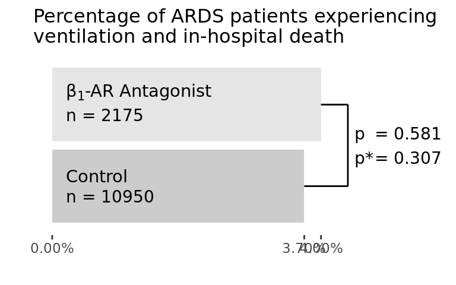

```r
p4 <- make_covid_plot(drug_outcome_0_0, drug_outcome_0_1, drug_outcome_1_0, drug_outcome_1_1,
                p, p_star, plot_title,receptor)
p4
```

# 2 Pneumonia

## 2.1 Alpha Blockers

### 2.1.1 Ventilation vs. Alpha

Alpha blockers are denoted as `drugs` in this table.

```r
#      vent.out
# drugs     0     1
#     0 94215  9243
#     1  5070   428

drug_outcome_0_0 <- 94215
drug_outcome_0_1 <- 9243
drug_outcome_1_0 <- 5070
drug_outcome_1_1 <- 428
```

#### 2.1.1.1 Unadjusted

Alpha blockers are denoted as `drugs` in this model.

```
Call:
glm(formula = vent.out ~ drugs, family = binomial(link = "logit"))

Deviance Residuals:
Min       1Q   Median       3Q      Max
-0.4326  -0.4326  -0.4326  -0.4326   2.2597

Coefficients:
Estimate Std. Error  z value Pr(>|z|)
(Intercept)  -2.3217     0.0109 -213.007  < 2e-16 ***
drugs        -0.1503     0.0515   -2.918  0.00353 **
---
Signif. codes:  0 ‘***’ 0.001 ‘**’ 0.01 ‘*’ 0.05 ‘.’ 0.1 ‘ ’ 1

(Dispersion parameter for binomial family taken to be 1)

Null deviance: 65300  on 108955  degrees of freedom
Residual deviance: 65291  on 108954  degrees of freedom
AIC: 65295

Number of Fisher Scoring iterations: 5

2.5 %    97.5 %
(Intercept) 0.0981054 0.09602576 0.1002175
drugs       0.8604842 0.77682866 0.9506586
```

```r
# OR, CI, and p statement example:
# OR 0.75, 95% CI (0.59, 0.94), p=0.015
p = 0.00353
OR_CI = c(0.8604842, 0.77682866, 0.9506586)
OR = OR_CI[1]
CI = OR_CI[2:3]
str_c("OR ", round(OR,2), ", 95% CI (", round(CI[1],2), ", ", round(CI[2],2), "), p=", round(p,3))
```

```
## [1] "OR 0.86, 95% CI (0.78, 0.95), p=0.004"
```

#### 2.1.1.2 Adjusted

Beta blockers are denoted as `drugs` in this model. Alpha blockers are denoted as `alpha.alt`.

```
Call:
glm(formula = vent.out ~ alpha.alt + drugs + YEARf + AGE + SEX +
AGE2 + AGE3 + DM + HTN + HF + IHD + AMI + COPD + PTSD, family = binomial(link = "logit"))

Deviance Residuals:
Min       1Q   Median       3Q      Max
-0.6707  -0.4426  -0.4244  -0.4044   2.5717

Coefficients: (1 not defined because of singularities)
Estimate Std. Error z value Pr(>|z|)
(Intercept) -6.424e+00  1.264e+01  -0.508 0.611304
alpha.alt   -1.839e-01  5.208e-02  -3.530 0.000415 ***
drugs       -1.128e-02  3.074e-02  -0.367 0.713550
YEARf2008    4.093e-01  1.508e-01   2.714 0.006648 **
YEARf2009    6.073e-01  1.492e-01   4.069 4.72e-05 ***
YEARf2010    6.089e-01  1.494e-01   4.077 4.56e-05 ***
YEARf2011    6.461e-01  1.491e-01   4.334 1.47e-05 ***
YEARf2012    6.200e-01  1.491e-01   4.158 3.21e-05 ***
YEARf2013    5.900e-01  1.500e-01   3.932 8.43e-05 ***
YEARf2014    7.574e-01  1.498e-01   5.057 4.26e-07 ***
YEARf2015    7.152e-01  1.523e-01   4.695 2.67e-06 ***
AGE          1.138e-01  6.954e-01   0.164 0.869973
SEX                 NA         NA      NA       NA
AGE2        -8.008e-04  1.268e-02  -0.063 0.949656
AGE3        -2.367e-06  7.670e-05  -0.031 0.975377
DM           3.326e-02  2.430e-02   1.369 0.171062
HTN          8.756e-02  2.363e-02   3.705 0.000211 ***
HF           2.358e-01  3.345e-02   7.050 1.78e-12 ***
IHD         -4.988e-02  2.873e-02  -1.736 0.082536 .
AMI          3.603e-01  6.386e-02   5.642 1.68e-08 ***
COPD        -4.647e-02  2.506e-02  -1.854 0.063702 .
PTSD         2.375e-01  1.323e-01   1.796 0.072570 .
---
Signif. codes:  0 ‘***’ 0.001 ‘**’ 0.01 ‘*’ 0.05 ‘.’ 0.1 ‘ ’ 1

(Dispersion parameter for binomial family taken to be 1)

Null deviance: 65300  on 108955  degrees of freedom
Residual deviance: 65053  on 108935  degrees of freedom
AIC: 65095
```

[output cut: 11 more lines]

```
YEARf2012   1.858876778 1.403674e+00 2.521392e+00
YEARf2013   1.803903582 1.359386e+00 2.451025e+00
YEARf2014   2.132630122 1.608073e+00 2.896220e+00
YEARf2015   2.044527940 1.533226e+00 2.789365e+00
AGE         1.120566975 2.872466e-01 4.387172e+00
SEX                  NA           NA           NA
AGE2        0.999199528 9.746397e-01 1.024323e+00
AGE3        0.999997633 9.998474e-01 1.000148e+00
DM          1.033821359 9.856519e-01 1.084160e+00
HTN         1.091503154 1.042126e+00 1.143270e+00
HF          1.265928043 1.185249e+00 1.351297e+00
IHD         0.951343367 8.990873e-01 1.006270e+00
AMI         1.433727172 1.263283e+00 1.622711e+00
COPD        0.954589490 9.086892e-01 1.002501e+00
PTSD        1.268025124 9.697405e-01 1.629944e+00
```

```r
# OR, CI, and p statement example:
# OR 0.75, 95% CI (0.59, 0.94), p=0.015
p_star = 0.000415
OR_CI = c(0.832059288, 7.503369e-01, 9.203247e-01)
OR = OR_CI[1]
CI = OR_CI[2:3]
str_c("AOR ", round(OR,2), ", 95% CI (", round(CI[1],2), ", ", round(CI[2],2), "), p=", round(p_star,4))
```

```
## [1] "AOR 0.83, 95% CI (0.75, 0.92), p=4e-04"
```

#### 2.1.1.3 Figure

Results for Figure:

```r
plot_title = "Percentage of pneumonia patients\nrequiring ventilation"
receptor = "alpha"
prop.test(x = c(drug_outcome_0_1,  # bad outcome controls
                drug_outcome_1_1), # bad outcome on drugs
          n = c(drug_outcome_0_0 + drug_outcome_0_1,  # total controls
                drug_outcome_1_0 + drug_outcome_1_1)) # total on drugs
```

```
##
##  2-sample test for equality of proportions with continuity correction
##
## data:  c(drug_outcome_0_1, drug_outcome_1_1) out of c(drug_outcome_0_0 + drug_outcome_0_1, drug_outcome_1_0 + drug_outcome_1_1)
## X-squared = 8.3859, df = 1, p-value = 0.003781
## alternative hypothesis: two.sided
## 95 percent confidence interval:
##  0.004106002 0.018882223
## sample estimates:
##     prop 1     prop 2
## 0.08934060 0.07784649
```

Figure:

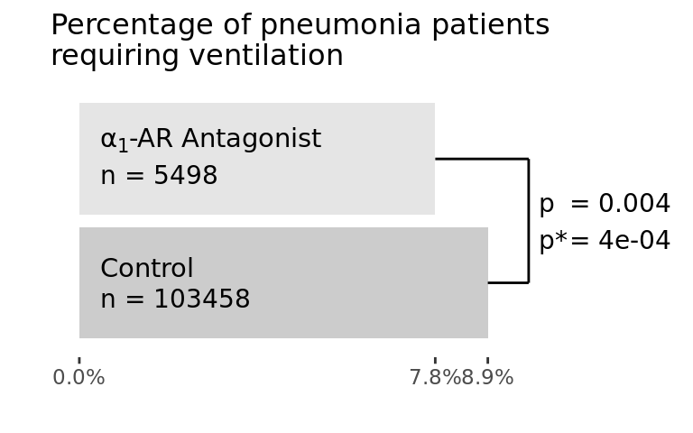

```r
p5 <- make_covid_plot(drug_outcome_0_0, drug_outcome_0_1, drug_outcome_1_0, drug_outcome_1_1,
                p, p_star, plot_title,receptor)
p5
```

### 2.1.2 Ventilation and Death vs. Alpha

Alpha blockers are denoted as `drugs` in this table.

```r
#      deathANDvent
# drugs      0      1
#     0 101262   2196
#     1   5400     98

drug_outcome_0_0 <- 101262
drug_outcome_0_1 <- 2196
drug_outcome_1_0 <- 5400
drug_outcome_1_1 <- 98
```

#### 2.1.2.1 Unadjusted

Alpha blockers are denoted as `drugs` in this model.

```
Call:
glm(formula = deathANDvent ~ drugs, family = binomial(link = "logit"))

Deviance Residuals:
Min       1Q   Median       3Q      Max
-0.2071  -0.2071  -0.2071  -0.2071   2.8380

Coefficients:
Estimate Std. Error z value Pr(>|z|)
(Intercept) -3.83107    0.02157 -177.62   <2e-16 ***
drugs       -0.17811    0.10417   -1.71   0.0873 .
---
Signif. codes:  0 ‘***’ 0.001 ‘**’ 0.01 ‘*’ 0.05 ‘.’ 0.1 ‘ ’ 1

(Dispersion parameter for binomial family taken to be 1)

Null deviance: 22252  on 108955  degrees of freedom
Residual deviance: 22249  on 108954  degrees of freedom
AIC: 22253

Number of Fisher Scoring iterations: 6

2.5 %     97.5 %
(Intercept) 0.02168632 0.02078264 0.02261636
drugs       0.83684783 0.67795550 1.02037249
```

```r
# OR, CI, and p statement example:
# OR 0.75, 95% CI (0.59, 0.94), p=0.015
p = 0.0873
OR_CI = c(0.83684783, 0.67795550, 1.02037249)
OR = OR_CI[1]
CI = OR_CI[2:3]
str_c("OR ", round(OR,2), ", 95% CI (", round(CI[1],2), ", ", round(CI[2],2), "), p=", round(p,3))
```

```
## [1] "OR 0.84, 95% CI (0.68, 1.02), p=0.087"
```

#### 2.1.2.2 Adjusted

Beta blockers are denoted as `drugs` in this model. Alpha blockers are denoted as `alpha.alt`.

```
Call:
glm(formula = deathANDvent ~ alpha.alt + drugs + YEARf + AGE +
SEX + AGE2 + AGE3 + DM + HTN + HF + IHD + AMI + COPD + PTSD,
family = binomial(link = "logit"))

Deviance Residuals:
Min       1Q   Median       3Q      Max
-0.2996  -0.2163  -0.2038  -0.1911   3.0771

Coefficients: (1 not defined because of singularities)
Estimate Std. Error z value Pr(>|z|)
(Intercept) -5.811e+01  2.661e+01  -2.184  0.02898 *
alpha.alt   -2.591e-01  1.052e-01  -2.464  0.01373 *
drugs       -7.760e-02  6.105e-02  -1.271  0.20374
YEARf2008    5.392e-01  3.256e-01   1.656  0.09774 .
YEARf2009    7.062e-01  3.228e-01   2.188  0.02871 *
YEARf2010    6.956e-01  3.231e-01   2.153  0.03130 *
YEARf2011    7.697e-01  3.224e-01   2.387  0.01697 *
YEARf2012    7.560e-01  3.224e-01   2.345  0.01901 *
YEARf2013    7.568e-01  3.239e-01   2.336  0.01947 *
YEARf2014    9.061e-01  3.234e-01   2.802  0.00508 **
YEARf2015    7.357e-01  3.291e-01   2.236  0.02537 *
AGE          2.745e+00  1.457e+00   1.884  0.05958 .
SEX                 NA         NA      NA       NA
AGE2        -4.690e-02  2.645e-02  -1.773  0.07623 .
AGE3         2.667e-04  1.593e-04   1.674  0.09403 .
DM           3.475e-02  4.773e-02   0.728  0.46655
HTN          1.119e-01  4.704e-02   2.379  0.01735 *
HF           3.307e-01  6.282e-02   5.265  1.4e-07 ***
IHD         -9.699e-03  5.541e-02  -0.175  0.86104
AMI          5.766e-02  1.323e-01   0.436  0.66292
COPD         1.138e-01  4.764e-02   2.390  0.01687 *
PTSD        -1.629e-01  3.054e-01  -0.533  0.59375
---
Signif. codes:  0 ‘***’ 0.001 ‘**’ 0.01 ‘*’ 0.05 ‘.’ 0.1 ‘ ’ 1

(Dispersion parameter for binomial family taken to be 1)

Null deviance: 22252  on 108955  degrees of freedom
Residual deviance: 22124  on 108935  degrees of freedom
```

[output cut: 12 more lines]

```
YEARf2012   2.129842e+00 1.196864e+00 4.292165e+00
YEARf2013   2.131414e+00 1.193322e+00 4.305882e+00
YEARf2014   2.474594e+00 1.387212e+00 4.994997e+00
YEARf2015   2.087038e+00 1.154117e+00 4.250792e+00
AGE         1.555878e+01 9.071043e-01 2.744337e+02
SEX                   NA           NA           NA
AGE2        9.541850e-01 9.057674e-01 1.004749e+00
AGE3        1.000267e+00 9.999556e-01 1.000580e+00
DM          1.035363e+00 9.425488e-01 1.136504e+00
HTN         1.118403e+00 1.020040e+00 1.226588e+00
HF          1.392001e+00 1.229272e+00 1.572600e+00
IHD         9.903476e-01 8.877800e-01 1.103182e+00
AMI         1.059356e+00 8.105339e-01 1.362480e+00
COPD        1.120562e+00 1.020110e+00 1.229573e+00
PTSD        8.496577e-01 4.384077e-01 1.468576e+00
```

```r
# OR, CI, and p statement example:
# OR 0.75, 95% CI (0.59, 0.94), p=0.015
p_star = 0.01373
OR_CI = c(7.717119e-01, 6.240621e-01, 9.428618e-01)
OR = OR_CI[1]
CI = OR_CI[2:3]
str_c("AOR ", round(OR,2), ", 95% CI (", round(CI[1],2), ", ", round(CI[2],2), "), p=", round(p_star,3))
```

```
## [1] "AOR 0.77, 95% CI (0.62, 0.94), p=0.014"
```

#### 2.1.2.3 Figure

Results for Figure:

```r
plot_title = "Percentage of pneumonia patients\nexperiencing ventilation\nand in-hospital death"
receptor = "alpha"
prop.test(x = c(drug_outcome_0_1,  # bad outcome controls
                drug_outcome_1_1), # bad outcome on drugs
          n = c(drug_outcome_0_0 + drug_outcome_0_1,  # total controls
                drug_outcome_1_0 + drug_outcome_1_1)) # total on drugs
```

```
##
##  2-sample test for equality of proportions with continuity correction
##
## data:  c(drug_outcome_0_1, drug_outcome_1_1) out of c(drug_outcome_0_0 + drug_outcome_0_1, drug_outcome_1_0 + drug_outcome_1_1)
## X-squared = 2.7676, df = 1, p-value = 0.09619
## alternative hypothesis: two.sided
## 95 percent confidence interval:
##  -0.0003004743  0.0071031567
## sample estimates:
##     prop 1     prop 2
## 0.02122600 0.01782466
```

Figure:

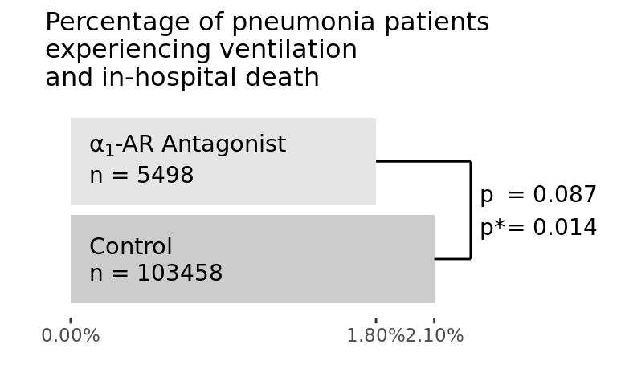

```r
p6 <- make_covid_plot(drug_outcome_0_0, drug_outcome_0_1, drug_outcome_1_0, drug_outcome_1_1,
                p, p_star, plot_title,receptor)
p6
```

## 2.2 Beta Blockers

### 2.2.1 Ventilation vs. Beta

Beta blockers are denoted as `drugs` in this table.

```r
#      vent.out
# drugs     0     1
#     0 84169  8162
#     1 15116  1509

drug_outcome_0_0 <- 84169
drug_outcome_0_1 <- 8162
drug_outcome_1_0 <- 15116
drug_outcome_1_1 <- 1509
```

#### 2.2.1.1 Unadjusted

Beta blockers are denoted as `drugs` in this model.

```
glm(formula = vent.out ~ drugs, family = binomial(link = "logit"))

Deviance Residuals:
Min       1Q   Median       3Q      Max
-0.4362  -0.4302  -0.4302  -0.4302   2.2027

Coefficients:
Estimate Std. Error  z value Pr(>|z|)
(Intercept) -2.33334    0.01159 -201.270   <2e-16 ***
drugs        0.02903    0.02938    0.988    0.323
---
Signif. codes:  0 ‘***’ 0.001 ‘**’ 0.01 ‘*’ 0.05 ‘.’ 0.1 ‘ ’ 1

(Dispersion parameter for binomial family taken to be 1)

Null deviance: 65300  on 108955  degrees of freedom
Residual deviance: 65299  on 108954  degrees of freedom
AIC: 65303

Number of Fisher Scoring iterations: 5
2.5 %     97.5 %
(Intercept) 0.09697157 0.09478627 0.09919318
drugs       1.02945634 0.97154199 1.09014263
```

```r
# OR, CI, and p statement example:
# OR 0.75, 95% CI (0.59, 0.94), p=0.015
p = 0.323
OR_CI = c(1.02945634, 0.97154199, 1.09014263)
OR = OR_CI[1]
CI = OR_CI[2:3]
str_c("OR ", round(OR,2), ", 95% CI (", round(CI[1],2), ", ", round(CI[2],2), "), p=", round(p,3))
```

```
## [1] "OR 1.03, 95% CI (0.97, 1.09), p=0.323"
```

#### 2.2.1.2 Adjusted

Beta blockers are denoted as `drugs` in this model. Alpha blockers are denoted as `alpha.alt`.

```
Call:
glm(formula = vent.out ~ alpha.alt + drugs + YEARf + AGE + SEX +
AGE2 + AGE3 + DM + HTN + HF + IHD + AMI + COPD + PTSD, family = binomial(link = "logit"))

Deviance Residuals:
Min       1Q   Median       3Q      Max
-0.6707  -0.4426  -0.4244  -0.4044   2.5717

Coefficients: (1 not defined because of singularities)
Estimate Std. Error z value Pr(>|z|)
(Intercept) -6.424e+00  1.264e+01  -0.508 0.611304
alpha.alt   -1.839e-01  5.208e-02  -3.530 0.000415 ***
drugs       -1.128e-02  3.074e-02  -0.367 0.713550
YEARf2008    4.093e-01  1.508e-01   2.714 0.006648 **
YEARf2009    6.073e-01  1.492e-01   4.069 4.72e-05 ***
YEARf2010    6.089e-01  1.494e-01   4.077 4.56e-05 ***
YEARf2011    6.461e-01  1.491e-01   4.334 1.47e-05 ***
YEARf2012    6.200e-01  1.491e-01   4.158 3.21e-05 ***
YEARf2013    5.900e-01  1.500e-01   3.932 8.43e-05 ***
YEARf2014    7.574e-01  1.498e-01   5.057 4.26e-07 ***
YEARf2015    7.152e-01  1.523e-01   4.695 2.67e-06 ***
AGE          1.138e-01  6.954e-01   0.164 0.869973
SEX                 NA         NA      NA       NA
AGE2        -8.008e-04  1.268e-02  -0.063 0.949656
AGE3        -2.367e-06  7.670e-05  -0.031 0.975377
DM           3.326e-02  2.430e-02   1.369 0.171062
HTN          8.756e-02  2.363e-02   3.705 0.000211 ***
HF           2.358e-01  3.345e-02   7.050 1.78e-12 ***
IHD         -4.988e-02  2.873e-02  -1.736 0.082536 .
AMI          3.603e-01  6.386e-02   5.642 1.68e-08 ***
COPD        -4.647e-02  2.506e-02  -1.854 0.063702 .
PTSD         2.375e-01  1.323e-01   1.796 0.072570 .
---
Signif. codes:  0 ‘***’ 0.001 ‘**’ 0.01 ‘*’ 0.05 ‘.’ 0.1 ‘ ’ 1

(Dispersion parameter for binomial family taken to be 1)

Null deviance: 65300  on 108955  degrees of freedom
Residual deviance: 65053  on 108935  degrees of freedom
AIC: 65095
```

[output cut: 11 more lines]

```
YEARf2012   1.858876778 1.403674e+00 2.521392e+00
YEARf2013   1.803903582 1.359386e+00 2.451025e+00
YEARf2014   2.132630122 1.608073e+00 2.896220e+00
YEARf2015   2.044527940 1.533226e+00 2.789365e+00
AGE         1.120566975 2.872466e-01 4.387172e+00
SEX                  NA           NA           NA
AGE2        0.999199528 9.746397e-01 1.024323e+00
AGE3        0.999997633 9.998474e-01 1.000148e+00
DM          1.033821359 9.856519e-01 1.084160e+00
HTN         1.091503154 1.042126e+00 1.143270e+00
HF          1.265928043 1.185249e+00 1.351297e+00
IHD         0.951343367 8.990873e-01 1.006270e+00
AMI         1.433727172 1.263283e+00 1.622711e+00
COPD        0.954589490 9.086892e-01 1.002501e+00
PTSD        1.268025124 9.697405e-01 1.629944e+00
```

```r
# OR, CI, and p statement example:
# OR 0.75, 95% CI (0.59, 0.94), p=0.015
p_star = 0.713550
OR_CI = c(0.988778569, 9.306964e-01, 1.049893e+00)
OR = OR_CI[1]
CI = OR_CI[2:3]
str_c("AOR ", round(OR,2), ", 95% CI (", round(CI[1],2), ", ", round(CI[2],2), "), p=", round(p_star,3))
```

```
## [1] "AOR 0.99, 95% CI (0.93, 1.05), p=0.714"
```

#### 2.2.1.3 Figure

Results for Figure:

```r
plot_title = "Percentage of pneumonia patients\nrequiring ventilation"
receptor = "beta"
prop.test(x = c(drug_outcome_0_1,  # bad outcome controls
                drug_outcome_1_1), # bad outcome on drugs
          n = c(drug_outcome_0_0 + drug_outcome_0_1,  # total controls
                drug_outcome_1_0 + drug_outcome_1_1)) # total on drugs
```

```
##
##  2-sample test for equality of proportions with continuity correction
##
## data:  c(drug_outcome_0_1, drug_outcome_1_1) out of c(drug_outcome_0_0 + drug_outcome_0_1, drug_outcome_1_0 + drug_outcome_1_1)
## X-squared = 0.94731, df = 1, p-value = 0.3304
## alternative hypothesis: two.sided
## 95 percent confidence interval:
##  -0.007138268  0.002403125
## sample estimates:
##     prop 1     prop 2
## 0.08839935 0.09076692
```

Figure:

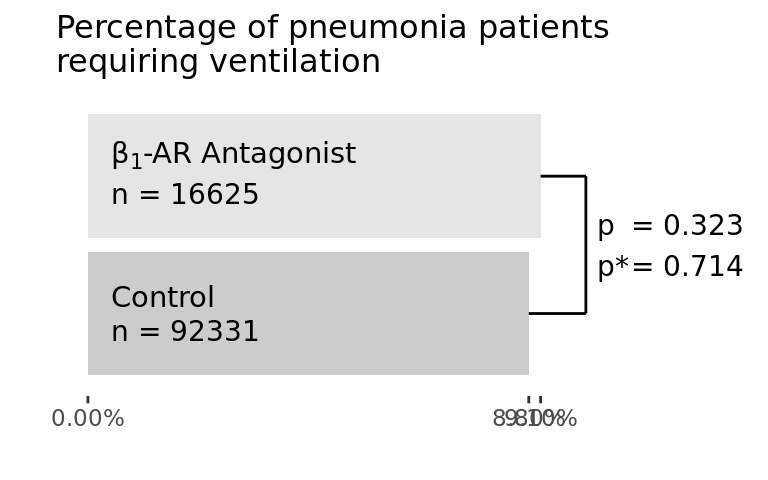

```r
p7 <- make_covid_plot(drug_outcome_0_0, drug_outcome_0_1, drug_outcome_1_0, drug_outcome_1_1,
                p, p_star, plot_title,receptor)
p7
```

### 2.2.2 Ventilation and Death vs. Beta

Beta blockers are denoted as `drugs` in this table.

```r
#      deathANDvent
# drugs     0     1
#     0 90388  1943
#     1 16274   351

drug_outcome_0_0 <- 90388
drug_outcome_0_1 <- 1943
drug_outcome_1_0 <- 16274
drug_outcome_1_1 <- 351
```

#### 2.2.2.1 Unadjusted

Beta blockers are denoted as `drugs` in this model.

```
glm(formula = deathANDvent ~ drugs, family = binomial(link = "logit"))

Deviance Residuals:
Min       1Q   Median       3Q      Max
-0.2066  -0.2062  -0.2062  -0.2062   2.7789

Coefficients:
Estimate Std. Error  z value Pr(>|z|)
(Intercept) -3.839878   0.022928 -167.476   <2e-16 ***
drugs        0.003341   0.058617    0.057    0.955
---
Signif. codes:  0 ‘***’ 0.001 ‘**’ 0.01 ‘*’ 0.05 ‘.’ 0.1 ‘ ’ 1

(Dispersion parameter for binomial family taken to be 1)

Null deviance: 22252  on 108955  degrees of freedom
Residual deviance: 22252  on 108954  degrees of freedom
AIC: 22256

Number of Fisher Scoring iterations: 6

2.5 %     97.5 %
(Intercept) 0.02149622 0.02054488 0.02247708
drugs       1.00334613 0.89310521 1.12389665
```

```r
# OR, CI, and p statement example:
# OR 0.75, 95% CI (0.59, 0.94), p=0.015
p = 0.955
OR_CI = c(1.00334613, 0.89310521, 1.12389665)
OR = OR_CI[1]
CI = OR_CI[2:3]
str_c("OR ", round(OR,2), ", 95% CI (", round(CI[1],2), ", ", round(CI[2],2), "), p=", round(p,3))
```

```
## [1] "OR 1, 95% CI (0.89, 1.12), p=0.955"
```

#### 2.2.2.2 Adjusted

Beta blockers are denoted as `drugs` in this model. Alpha blockers are denoted as `alpha.alt`.

```
Call:
glm(formula = deathANDvent ~ alpha.alt + drugs + YEARf + AGE +
SEX + AGE2 + AGE3 + DM + HTN + HF + IHD + AMI + COPD + PTSD,
family = binomial(link = "logit"))

Deviance Residuals:
Min       1Q   Median       3Q      Max
-0.2996  -0.2163  -0.2038  -0.1911   3.0771

Coefficients: (1 not defined because of singularities)
Estimate Std. Error z value Pr(>|z|)
(Intercept) -5.811e+01  2.661e+01  -2.184  0.02898 *
alpha.alt   -2.591e-01  1.052e-01  -2.464  0.01373 *
drugs       -7.760e-02  6.105e-02  -1.271  0.20374
YEARf2008    5.392e-01  3.256e-01   1.656  0.09774 .
YEARf2009    7.062e-01  3.228e-01   2.188  0.02871 *
YEARf2010    6.956e-01  3.231e-01   2.153  0.03130 *
YEARf2011    7.697e-01  3.224e-01   2.387  0.01697 *
YEARf2012    7.560e-01  3.224e-01   2.345  0.01901 *
YEARf2013    7.568e-01  3.239e-01   2.336  0.01947 *
YEARf2014    9.061e-01  3.234e-01   2.802  0.00508 **
YEARf2015    7.357e-01  3.291e-01   2.236  0.02537 *
AGE          2.745e+00  1.457e+00   1.884  0.05958 .
SEX                 NA         NA      NA       NA
AGE2        -4.690e-02  2.645e-02  -1.773  0.07623 .
AGE3         2.667e-04  1.593e-04   1.674  0.09403 .
DM           3.475e-02  4.773e-02   0.728  0.46655
HTN          1.119e-01  4.704e-02   2.379  0.01735 *
HF           3.307e-01  6.282e-02   5.265  1.4e-07 ***
IHD         -9.699e-03  5.541e-02  -0.175  0.86104
AMI          5.766e-02  1.323e-01   0.436  0.66292
COPD         1.138e-01  4.764e-02   2.390  0.01687 *
PTSD        -1.629e-01  3.054e-01  -0.533  0.59375
---
Signif. codes:  0 ‘***’ 0.001 ‘**’ 0.01 ‘*’ 0.05 ‘.’ 0.1 ‘ ’ 1

(Dispersion parameter for binomial family taken to be 1)

Null deviance: 22252  on 108955  degrees of freedom
Residual deviance: 22124  on 108935  degrees of freedom
```

[output cut: 12 more lines]

```
YEARf2012   2.129842e+00 1.196864e+00 4.292165e+00
YEARf2013   2.131414e+00 1.193322e+00 4.305882e+00
YEARf2014   2.474594e+00 1.387212e+00 4.994997e+00
YEARf2015   2.087038e+00 1.154117e+00 4.250792e+00
AGE         1.555878e+01 9.071043e-01 2.744337e+02
SEX                   NA           NA           NA
AGE2        9.541850e-01 9.057674e-01 1.004749e+00
AGE3        1.000267e+00 9.999556e-01 1.000580e+00
DM          1.035363e+00 9.425488e-01 1.136504e+00
HTN         1.118403e+00 1.020040e+00 1.226588e+00
HF          1.392001e+00 1.229272e+00 1.572600e+00
IHD         9.903476e-01 8.877800e-01 1.103182e+00
AMI         1.059356e+00 8.105339e-01 1.362480e+00
COPD        1.120562e+00 1.020110e+00 1.229573e+00
PTSD        8.496577e-01 4.384077e-01 1.468576e+00
```

```r
# OR, CI, and p statement example:
# OR 0.75, 95% CI (0.59, 0.94), p=0.015
p_star = 0.20374
OR_CI = c(9.253387e-01, 8.198570e-01, 1.041606e+00)
OR = OR_CI[1]
CI = OR_CI[2:3]
str_c("AOR ", round(OR,2), ", 95% CI (", round(CI[1],2), ", ", round(CI[2],2), "), p=", round(p_star,3))
```

```
## [1] "AOR 0.93, 95% CI (0.82, 1.04), p=0.204"
```

#### 2.2.2.3 Figure

Results for Figure:

```r
plot_title = "Percentage of pneumonia patients\nexperiencing ventilation\nand in-hospital death"
receptor = "beta"
prop.test(x = c(drug_outcome_0_1,  # bad outcome controls
                drug_outcome_1_1), # bad outcome on drugs
          n = c(drug_outcome_0_0 + drug_outcome_0_1,  # total controls
                drug_outcome_1_0 + drug_outcome_1_1)) # total on drugs
```

```
##
##  2-sample test for equality of proportions with continuity correction
##
## data:  c(drug_outcome_0_1, drug_outcome_1_1) out of c(drug_outcome_0_0 + drug_outcome_0_1, drug_outcome_1_0 + drug_outcome_1_1)
## X-squared = 0.00076427, df = 1, p-value = 0.9779
## alternative hypothesis: two.sided
## 95 percent confidence interval:
##  -0.002477717  0.002339860
## sample estimates:
##     prop 1     prop 2
## 0.02104385 0.02111278
```

Figure:

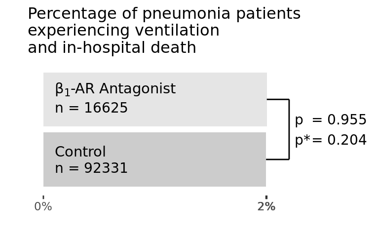

```r
p8 <- make_covid_plot(drug_outcome_0_0, drug_outcome_0_1, drug_outcome_1_0, drug_outcome_1_1,
                p, p_star, plot_title,receptor)
p8
```

# 3 Final Figures

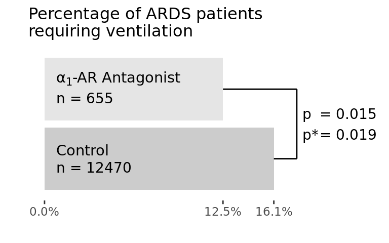

```r
p1
```

```r
ggsave("figure_1_1.pdf", width = 5, height = 2.5, units = "in")
```

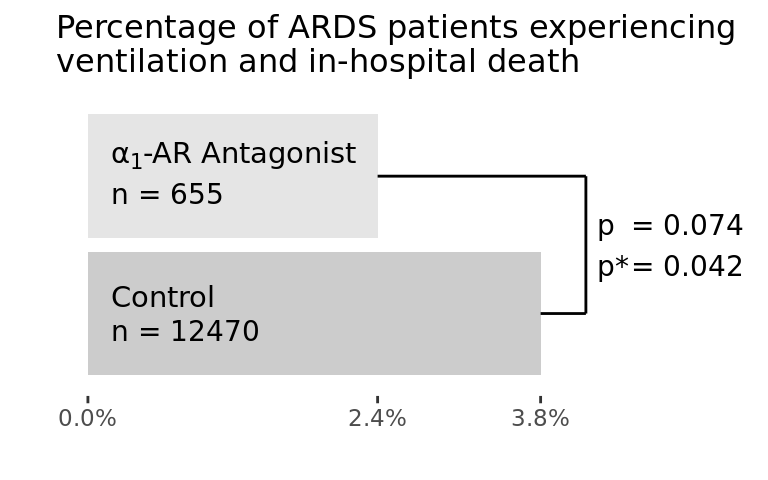

```r
p2
```

```r
ggsave("figure_1_2.pdf", width = 5, height = 2.5, units = "in")
```

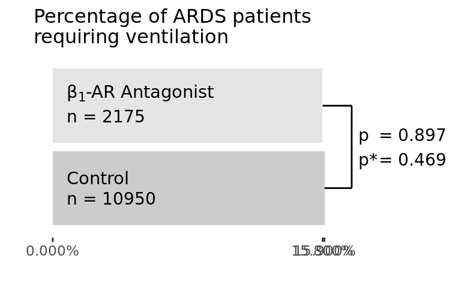

```r
p3
```

```r
ggsave("figure_1_3.pdf", width = 5, height = 2.5, units = "in")
```

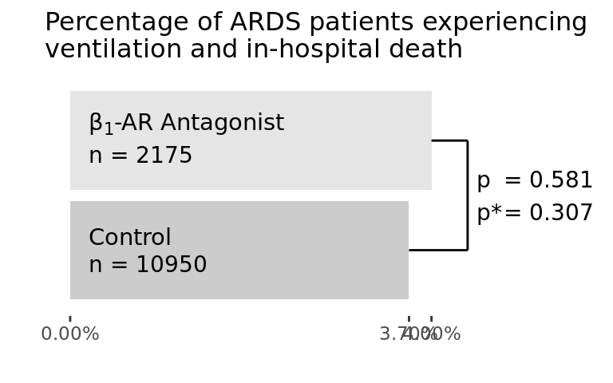

```r
p4
```

```r
ggsave("figure_1_4.pdf", width = 5, height = 2.5, units = "in")
```

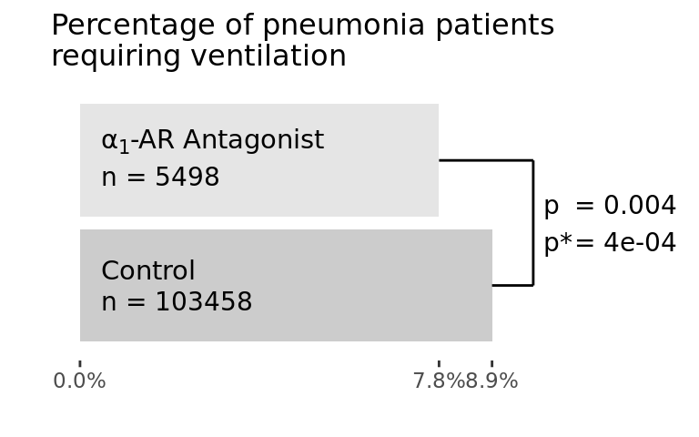

```r
p5
```

```r
ggsave("figure_1_5.pdf", width = 5, height = 2.5, units = "in")
```

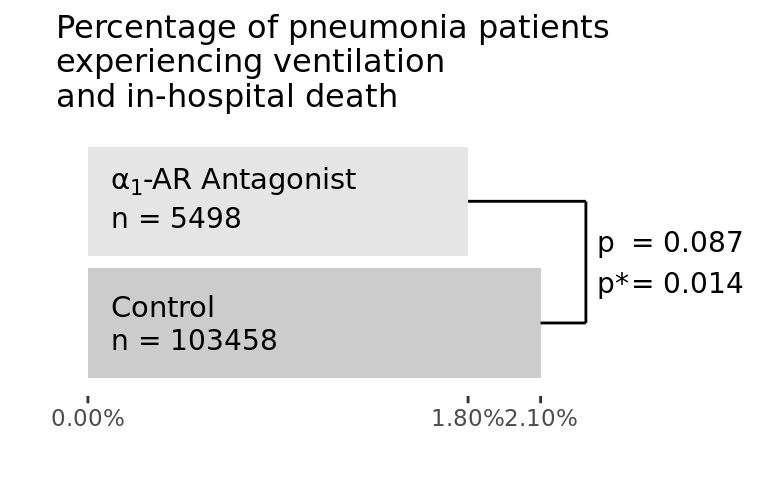

```r
p6
```

```r
ggsave("figure_1_6.pdf", width = 5, height = 2.5, units = "in")
```

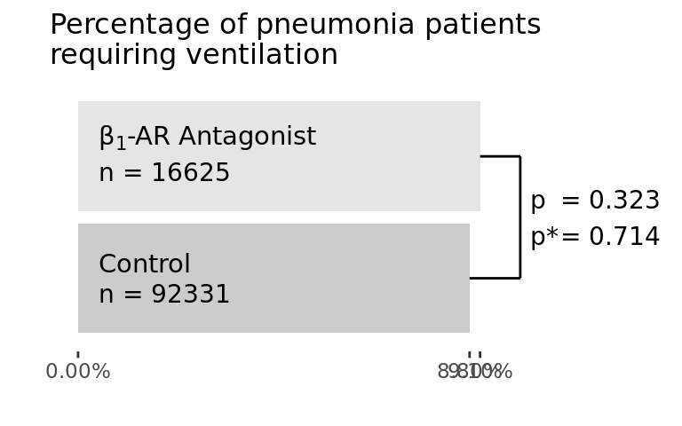

```r
p7
```

```r
ggsave("figure_1_7.pdf", width = 5, height = 2.5, units = "in")
```

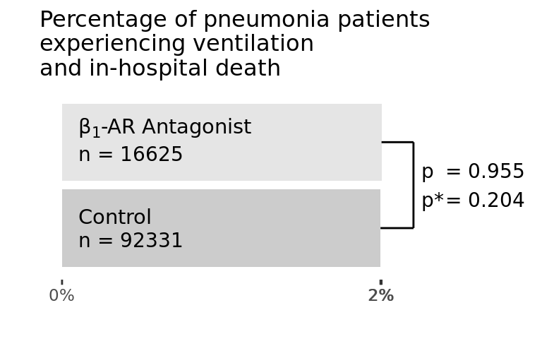

```r
p8
```

```r
ggsave("figure_1_8.pdf", width = 5, height = 2.5, units = "in")
```

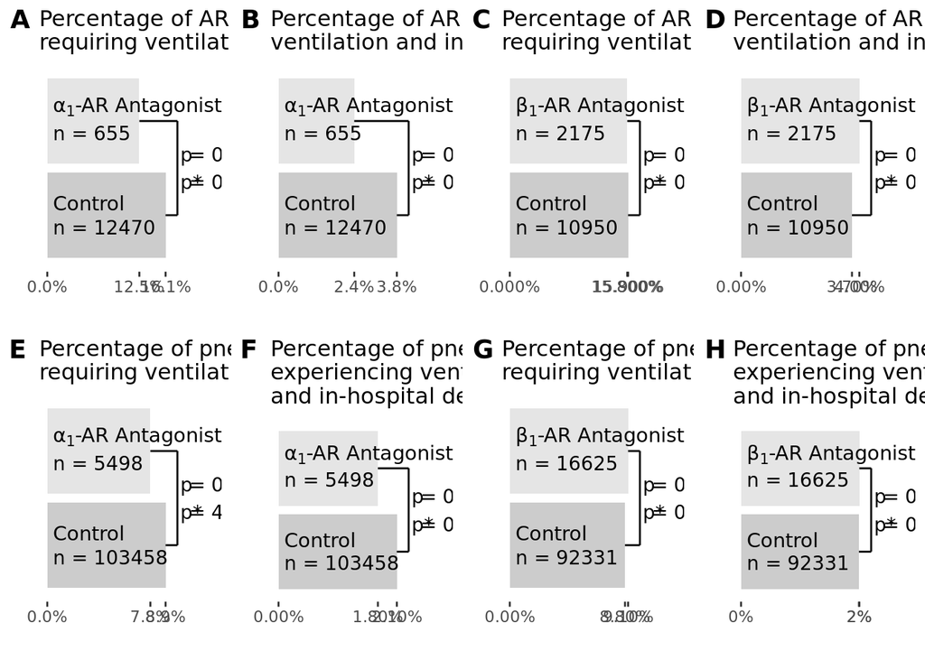

```r
ggarrange(p1, p2, p3, p4, p5, p6, p7, p8, labels = c("A", "B", "C", "D", "E", "F", "G", "H"),
          ncol = 4, nrow = 2)
```

```r
ggsave("figure_1_all.pdf", width = 16, height = 5, units = "in")
```